# Assignment 2: Spatial Analysis and Visualization

Healthcare Access and Equity in Pennsylvania

Author

Zhiyuan Zhao

Published

October 2, 2025

## Assignment Overview

**Learning Objectives:** - Apply spatial operations to answer policy-relevant research questions - Integrate census demographic data with spatial analysis - Create publication-quality visualizations and maps - Work with spatial data from multiple sources - Communicate findings effectively for policy audiences

## Part 1: Healthcare Access for Vulnerable Populations

### Research Question

**Which Pennsylvania counties have the highest proportion of vulnerable populations (elderly + low-income) living far from hospitals?**

Your analysis should identify counties that should be priorities for healthcare investment and policy intervention.

### Required Analysis Steps

Complete the following analysis, documenting each step with code and brief explanations:

#### Step 1: Data Collection (5 points)

Load the required spatial data: - Pennsylvania county boundaries - Pennsylvania hospitals (from lecture data) - Pennsylvania census tracts

**Your Task:**

```r
# Load required packages
library(sf)
library(tidyverse)
library(tidycensus)
library(tigris)
library(ggplot2)
library(knitr)
library(kableExtra)
library(units)
library(patchwork)
library(ggspatial)
```

```r
# Load spatial data
library(here)

pa_counties <- st_read(here::here("Assignments", "assignment_2", "data", "Pennsylvania_County_Boundaries.shp"))
hospitals   <- st_read(here::here("Assignments", "assignment_2", "data", "hospitals.geojson"))
# Pennsylvania census tracts
pa_tracts <- tracts("PA", year = 2022, cb = TRUE, progress = FALSE)

# Check that all data loaded correctly
cat("Number of hospitals:", nrow(hospitals), "\n")
```

```
Number of hospitals: 223
```

```r
cat("Number of census tracts", nrow(pa_tracts), "\n")
```

```
Number of census tracts 3445
```

```r
# CRS info
cat("Counties CRS:", st_crs(pa_counties)$input, "\n")
```

```
Counties CRS: WGS 84 / Pseudo-Mercator
```

```r
cat("Hospitals CRS:", st_crs(hospitals)$input, "\n")
```

```
Hospitals CRS: WGS 84
```

```r
cat("Census tracts CRS:", st_crs(pa_tracts)$input, "\n")
```

```
Census tracts CRS: NAD83
```

**Questions to answer:** 1. How many hospitals are in your dataset? 223 2. How many census tracts? 3445 3. What coordinate reference system is each dataset in? Counties CRS: WGS 84 / Pseudo-Mercator Hospitals CRS: WGS 84 Census tracts CRS: NAD83 ————————————————————————

#### Step 2: Get Demographic Data

Use `tidycensus` to download tract-level demographic data for Pennsylvania.

**Required variables:** - Total population - Median household income - Population 65 years and over (you may need to sum multiple age categories)

**Your Task:**

```r
# Get demographic data from ACS
pa_demo <- get_acs(
  geography = "tract",
  state = "PA",
  variables = c(
    total_pop = "B01003_001",
    median_income = "B19013_001",
    pop_65_74 = "B01001_020",
    pop_75_84 = "B01001_021",
    pop_85p = "B01001_022",
    progress = FALSE
  ),
  year = 2022,
  geometry = TRUE
)

# Pivot the data to wide format
pa_demo_wide <- pa_demo %>%
  select(GEOID, NAME, variable, estimate) %>%
  pivot_wider(
    names_from = variable, values_from = estimate,
    values_fill = 0
  ) %>%
  mutate(
    pop_65p = rowSums(across(c(pop_65_74, pop_75_84, pop_85p)), na.rm = TRUE),
    elderly_pct = 100 * pop_65p / total_pop
  )

# Join to tract boundaries
tracts_with_demo <- pa_demo_wide

# Check for missing data
cat("Missing income data:", sum(is.na(tracts_with_demo$median_income)), "\n")
```

```
Missing income data: 63
```

```r
cat("PA Median income: $",
    median(tracts_with_demo$median_income, na.rm = TRUE), "\n")
```

```
PA Median income: $ 70188
```

**Questions to answer:** - What year of ACS data are you using? 2022 - How many tracts have missing income data? 63 - What is the median income across all PA census tracts? 70188

#### Step 3: Define Vulnerable Populations

Identify census tracts with vulnerable populations based on TWO criteria: 1. Low median household income (choose an appropriate threshold) 2. Significant elderly population (choose an appropriate threshold)

**Your Task:**

```r
# Filter for vulnerable tracts based on your criteria
# Define thresholds
income_threshold <- 50000
elderly_threshold <- 10

# Identify vulnerable tracts
vulnerable_tracts <- tracts_with_demo %>%
  filter(!is.na(median_income)) %>%
  mutate(
    low_income = median_income < income_threshold,
    sign_elderly = elderly_pct > elderly_threshold,
    vulnerable = low_income | sign_elderly
  )

# Summaries
summary_vals <- list(
  pa_median = median(tracts_with_demo$median_income, na.rm = TRUE),
  n_vul = sum(vulnerable_tracts$vulnerable),
  pct_vul = round(mean(vulnerable_tracts$vulnerable) * 100, 1),
  n_low = sum(vulnerable_tracts$low_income),
  n_old = sum(vulnerable_tracts$sign_elderly)
)

cat(glue::glue(
  "Income threshold: ${income_threshold} \n",
  "Elderly threshold: {elderly_threshold}%\n",
  "Vulnerable tracts: {summary_vals$n_vul} ({summary_vals$pct_vul}%)\n",
  "Low median household income: {summary_vals$n_low}\n",
  "Significant elderly population: {summary_vals$n_old}\n"
))
```

```
Income threshold: $50000
Elderly threshold: 10%
Vulnerable tracts: 700 (20.7%)
Low median household income: 619
Significant elderly population: 98
```

**Questions to answer:** - What income threshold did you choose and why? Income threshold chosen: $50,000. This represents census tracts where the median household income is below roughly 70% of Pennsylvania’s overall median, marking areas that are relatively economically disadvantaged.

- What elderly population threshold did you choose and why? Elderly population threshold chosen: 10%. Tracts where more than 10% of residents are aged 65 or older were considered to have a significant elderly population, a common demographic baseline in vulnerability analyses.
- How many tracts meet your vulnerability criteria? 700 census tracts meet at least one of the two conditions
- What percentage of PA census tracts are considered vulnerable by your definition? 20.7%

#### Step 4: Calculate Distance to Hospitals

For each vulnerable tract, calculate the distance to the nearest hospital.

**Your Task:**

```r
# Transform to appropriate projected CRS
# EPSG 2272 is optimized for southern Pennsylvania counties such as Philadelphia, Lancaster, Chester, and York
target_crs <- 2272

# Reproject all layers
pa_counties_p <- st_transform(pa_counties, target_crs)
hospitals_p   <- st_transform(hospitals,   target_crs)
vul_p         <- st_transform(vulnerable_tracts, target_crs)

# Calculate distance from each tract centroid to nearest hospital
# tract centroids
vul_centroids <- st_centroid(vul_p)

# nearest hospital index
nn_idx <- st_nearest_feature(vul_centroids, hospitals_p)

# distance in feet -> miles
dists_ft <- st_distance(vul_centroids, hospitals_p[nn_idx, ], by_element = TRUE)
dists_mi <- units::set_units(dists_ft, "mi") |> units::drop_units()

# attach results
vulnerable_tracts_dist <- vul_p |>
  mutate(
    nearest_hosp_idx = as.integer(nn_idx),
    dist_to_hosp_mi  = dists_mi
  )

# join hospital name if a name field exists
name_field <- intersect(c("NAME","Name","name","HOSP_NAME","HOSPITAL","HospName"), names(hospitals_p))[1]
if (!is.na(name_field)) {
  vulnerable_tracts_dist <- vulnerable_tracts_dist |>
    mutate(nearest_hosp_name = hospitals_p[[name_field]][nearest_hosp_idx])
}

# summary statistics
avg_dist <- mean(vulnerable_tracts_dist$dist_to_hosp_mi, na.rm = TRUE)
min_dist <- min(vulnerable_tracts_dist$dist_to_hosp_mi, na.rm = TRUE)
max_dist <- max(vulnerable_tracts_dist$dist_to_hosp_mi, na.rm = TRUE)
n_over15 <- sum(vulnerable_tracts_dist$dist_to_hosp_mi > 15, na.rm = TRUE)

cat(
  "Average distance to nearest hospital:", round(avg_dist, 2), "miles\n",
  "Minimum distance:", round(min_dist, 2), "miles\n",
  "Maximum distance:", round(max_dist, 2), "miles\n",
  "Number of tracts more than 15 miles from nearest hospital:", n_over15, "\n"
)
```

```
Average distance to nearest hospital: 4.43 miles
 Minimum distance: 0.02 miles
 Maximum distance: 32.84 miles
 Number of tracts more than 15 miles from nearest hospital: 127
```

**Requirements:** - Use an appropriate projected coordinate system for Pennsylvania - Calculate distances in miles - Explain why you chose your projection

**Questions to answer:** - What is the average distance to the nearest hospital for vulnerable tracts? 4.43 miles

#### Step 5: Identify Underserved Areas

Define “underserved” as vulnerable tracts that are more than 15 miles from the nearest hospital.

**Your Task:**

```r
# Create underserved variable
# Definition: vulnerable tracts with distance > 15 miles

vulnerable_tracts_dist <- vulnerable_tracts_dist %>%
  mutate(underserved = dist_to_hosp_mi > 15)

# Counts and percentages
n_underserved  <- sum(vulnerable_tracts_dist$underserved, na.rm = TRUE)
n_with_dist    <- sum(!is.na(vulnerable_tracts_dist$dist_to_hosp_mi))
n_vulnerable   <- nrow(vulnerable_tracts_dist)
pct_underserved <- round(100 * n_underserved / n_with_dist, 1)

cat(
  "Underserved tracts:", n_underserved, "\n",
  "Percent underserved (of tracts with a distance):", pct_underserved, "%\n",
  "Vulnerable tracts total:", n_vulnerable, "\n",
  "With valid distance:", n_with_dist, "\n"
)
```

```
Underserved tracts: 127
 Percent underserved (of tracts with a distance): 3.8 %
 Vulnerable tracts total: 3383
 With valid distance: 3383
```

**Questions to answer:** - How many tracts are underserved? 127

#### Step 6: Aggregate to County Level

Use spatial joins and aggregation to calculate county-level statistics about vulnerable populations and hospital access.

**Your Task:**

```r
# find county name field in pa_counties_p
county_name_field <- intersect(
  c("NAME","NAME20","NAMELSAD","COUNTY","COUNTY_NAM","COUNTYNAME","County","county","NAME10"),
  names(pa_counties_p)
)[1]

if (is.na(county_name_field)) {
  stop("Cannot find a county name field in pa_counties_p. Inspect names(pa_counties_p).")
}

# keep only county name + geometry, and rename to COUNTY
counties_min <- pa_counties_p %>%
  dplyr::select(COUNTY = all_of(county_name_field), geometry)

# spatial join tracts -> counties
tracts_county <- st_join(vulnerable_tracts_dist, counties_min, join = st_intersects, left = FALSE)

# aggregate by COUNTY
county_summary <- tracts_county %>%
  st_drop_geometry() %>%
  dplyr::group_by(COUNTY) %>%
  dplyr::summarise(
    n_vulnerable        = dplyr::n(),
    n_underserved       = sum(underserved, na.rm = TRUE),
    pct_underserved     = round(100 * n_underserved / n_vulnerable, 1),
    avg_dist_mi         = round(mean(dist_to_hosp_mi, na.rm = TRUE), 2),
    total_vulnerable_pop= sum(total_pop, na.rm = TRUE)
  ) %>%
  dplyr::arrange(dplyr::desc(pct_underserved))

# table + tops
kable(county_summary, caption = "County-level Healthcare Accessibility Summary") %>%
  kable_styling(full_width = FALSE)
```

County-level Healthcare Accessibility Summary

| COUNTY | n_vulnerable | n_underserved | pct_underserved | avg_dist_mi | total_vulnerable_pop |
| --- | --- | --- | --- | --- | --- |
| JUNIATA | 20 | 12 | 60.0 | 14.64 | 80130 |
| SULLIVAN | 13 | 7 | 53.8 | 16.75 | 39765 |
| PIKE | 36 | 18 | 50.0 | 16.63 | 90387 |
| SNYDER | 17 | 8 | 47.1 | 14.14 | 76506 |
| CAMERON | 11 | 5 | 45.5 | 13.46 | 31227 |
| POTTER | 15 | 6 | 40.0 | 12.09 | 44065 |
| BRADFORD | 23 | 8 | 34.8 | 12.41 | 82113 |
| CLEARFIELD | 35 | 11 | 31.4 | 12.11 | 133305 |
| PERRY | 29 | 9 | 31.0 | 11.24 | 136944 |
| TIOGA | 17 | 5 | 29.4 | 11.18 | 60999 |
| CLINTON | 20 | 5 | 25.0 | 11.15 | 70796 |
| UNION | 24 | 6 | 25.0 | 9.61 | 104402 |
| WYOMING | 20 | 5 | 25.0 | 12.71 | 71055 |
| ELK | 19 | 4 | 21.1 | 10.51 | 64927 |
| WAYNE | 35 | 7 | 20.0 | 10.16 | 101863 |
| MONROE | 71 | 14 | 19.7 | 10.32 | 239844 |
| MIFFLIN | 26 | 5 | 19.2 | 8.72 | 86713 |
| SUSQUEHANNA | 21 | 4 | 19.0 | 10.20 | 69376 |
| FULTON | 11 | 2 | 18.2 | 11.78 | 45546 |
| FOREST | 12 | 2 | 16.7 | 11.67 | 32266 |
| MCKEAN | 19 | 3 | 15.8 | 8.82 | 54243 |
| CENTRE | 53 | 7 | 13.2 | 7.77 | 205338 |
| NORTHUMBERLAND | 39 | 5 | 12.8 | 10.05 | 157577 |
| CHESTER | 157 | 20 | 12.7 | 6.65 | 680335 |
| CLARION | 25 | 3 | 12.0 | 9.22 | 83316 |
| DAUPHIN | 83 | 10 | 12.0 | 5.60 | 358417 |
| CRAWFORD | 37 | 4 | 10.8 | 8.42 | 135400 |
| HUNTINGDON | 28 | 3 | 10.7 | 9.37 | 103995 |
| SCHUYLKILL | 62 | 6 | 9.7 | 7.48 | 222698 |
| LANCASTER | 136 | 12 | 8.8 | 5.98 | 641211 |
| LYCOMING | 47 | 4 | 8.5 | 6.26 | 173737 |
| WARREN | 24 | 2 | 8.3 | 6.84 | 80752 |
| JEFFERSON | 26 | 2 | 7.7 | 7.56 | 94634 |
| SOMERSET | 39 | 3 | 7.7 | 7.43 | 138787 |
| ERIE | 77 | 5 | 6.5 | 5.59 | 292643 |
| FRANKLIN | 46 | 3 | 6.5 | 5.94 | 212297 |
| VENANGO | 33 | 2 | 6.1 | 8.34 | 102067 |
| CARBON | 35 | 2 | 5.7 | 7.34 | 134867 |
| ARMSTRONG | 39 | 2 | 5.1 | 8.49 | 137004 |
| BEDFORD | 23 | 1 | 4.3 | 8.73 | 93406 |
| CUMBERLAND | 80 | 3 | 3.8 | 5.90 | 370539 |
| FAYETTE | 59 | 2 | 3.4 | 6.56 | 191334 |
| LUZERNE | 119 | 4 | 3.4 | 5.16 | 388640 |
| COLUMBIA | 30 | 1 | 3.3 | 6.45 | 120618 |
| YORK | 135 | 4 | 3.0 | 5.24 | 568950 |
| LACKAWANNA | 76 | 2 | 2.6 | 3.88 | 270270 |
| INDIANA | 40 | 1 | 2.5 | 7.07 | 142235 |
| ADAMS | 45 | 1 | 2.2 | 6.34 | 185064 |
| LEBANON | 47 | 1 | 2.1 | 5.33 | 203190 |
| BUTLER | 65 | 1 | 1.5 | 5.96 | 269083 |
| ALLEGHENY | 419 | 0 | 0.0 | 2.49 | 1375774 |
| BEAVER | 72 | 0 | 0.0 | 5.20 | 240367 |
| BERKS | 130 | 0 | 0.0 | 4.61 | 543881 |
| BLAIR | 53 | 0 | 0.0 | 4.99 | 181183 |
| BUCKS | 181 | 0 | 0.0 | 3.66 | 801951 |
| CAMBRIA | 59 | 0 | 0.0 | 6.03 | 195090 |
| DELAWARE | 172 | 0 | 0.0 | 2.33 | 671006 |
| GREENE | 18 | 0 | 0.0 | 8.41 | 66760 |
| LAWRENCE | 37 | 0 | 0.0 | 6.04 | 129315 |
| LEHIGH | 108 | 0 | 0.0 | 3.31 | 482921 |
| MERCER | 43 | 0 | 0.0 | 4.81 | 140781 |
| MONTGOMERY | 300 | 0 | 0.0 | 2.49 | 1218103 |
| MONTOUR | 14 | 0 | 0.0 | 5.14 | 67844 |
| NORTHAMPTON | 94 | 0 | 0.0 | 4.29 | 394848 |
| PHILADELPHIA | 422 | 0 | 0.0 | 1.13 | 1746810 |
| WASHINGTON | 84 | 0 | 0.0 | 4.67 | 308585 |
| WESTMORELAND | 156 | 0 | 0.0 | 4.63 | 507125 |

```r
top5_pct <- county_summary %>%
  dplyr::slice_max(pct_underserved, n = 5) %>%
  dplyr::select(COUNTY, pct_underserved)

top5_pop <- county_summary %>%
  dplyr::slice_max(total_vulnerable_pop, n = 5) %>%
  dplyr::select(COUNTY, total_vulnerable_pop)

cat("Top 5 counties by % underserved:\n"); print(top5_pct)
```

```
Top 5 counties by % underserved:
```

```
# A tibble: 5 × 2
  COUNTY   pct_underserved
  <chr>              <dbl>
1 JUNIATA             60
2 SULLIVAN            53.8
3 PIKE                50
4 SNYDER              47.1
5 CAMERON             45.5
```

```r
cat("\nTop 5 counties by total vulnerable population:\n"); print(top5_pop)
```

```
Top 5 counties by total vulnerable population:
```

```
# A tibble: 5 × 2
  COUNTY       total_vulnerable_pop
  <chr>                       <dbl>
1 PHILADELPHIA              1746810
2 ALLEGHENY                 1375774
3 MONTGOMERY                1218103
4 BUCKS                      801951
5 CHESTER                    680335
```

**Required county-level statistics:** - Number of vulnerable tracts - Number of underserved tracts  
- Percentage of vulnerable tracts that are underserved - Average distance to nearest hospital for vulnerable tracts - Total vulnerable population

**Questions to answer:** - Which 5 counties have the highest percentage of underserved vulnerable tracts? JUNIATA, SULLIVAN, PIKE, SNYDER, CAMERON

#### Step 7: Create Summary Table

Create a professional table showing the top 10 priority counties for healthcare investment.

**Your Task:**

```r
# Create and format priority counties table
# Priority rule: sort by % underserved (desc), then avg distance (desc),
# then # underserved tracts (desc), then vulnerable population (desc)

priority_tbl <- county_summary %>%
  arrange(desc(pct_underserved), desc(avg_dist_mi), desc(n_underserved), desc(total_vulnerable_pop)) %>%
  slice_head(n = 10) %>%
  transmute(
    County = COUNTY,
    `Vulnerable tracts`   = scales::comma(n_vulnerable),
    `Underserved tracts`  = scales::comma(n_underserved),
    `% underserved`       = scales::number(pct_underserved, accuracy = 0.1),
    `Avg distance (mi)`   = scales::number(avg_dist_mi, accuracy = 0.01),
    `Vulnerable population` = scales::comma(total_vulnerable_pop)
  )

kable(
  priority_tbl,
  caption = "Top 10 Priority Counties for Healthcare Investment (sorted by % underserved, distance, underserved count, population)"
) %>%
  kable_styling(full_width = FALSE)
```

Top 10 Priority Counties for Healthcare Investment (sorted by % underserved, distance, underserved count, population)

| County | Vulnerable tracts | Underserved tracts | % underserved | Avg distance (mi) | Vulnerable population |
| --- | --- | --- | --- | --- | --- |
| JUNIATA | 20 | 12 | 60.0 | 14.64 | 80,130 |
| SULLIVAN | 13 | 7 | 53.8 | 16.75 | 39,765 |
| PIKE | 36 | 18 | 50.0 | 16.63 | 90,387 |
| SNYDER | 17 | 8 | 47.1 | 14.14 | 76,506 |
| CAMERON | 11 | 5 | 45.5 | 13.46 | 31,227 |
| POTTER | 15 | 6 | 40.0 | 12.09 | 44,065 |
| BRADFORD | 23 | 8 | 34.8 | 12.41 | 82,113 |
| CLEARFIELD | 35 | 11 | 31.4 | 12.11 | 133,305 |
| PERRY | 29 | 9 | 31.0 | 11.24 | 136,944 |
| TIOGA | 17 | 5 | 29.4 | 11.18 | 60,999 |

**Requirements:** - Use `knitr::kable()` or similar for formatting - Include descriptive column names - Format numbers appropriately (commas for population, percentages, etc.) - Add an informative caption - Sort by priority (you decide the metric)

## Part 2: Comprehensive Visualization

Using the skills from Week 3 (Data Visualization), create publication-quality maps and charts.

### Map 1: County-Level Choropleth

Create a choropleth map showing healthcare access challenges at the county level.

**Your Task:**

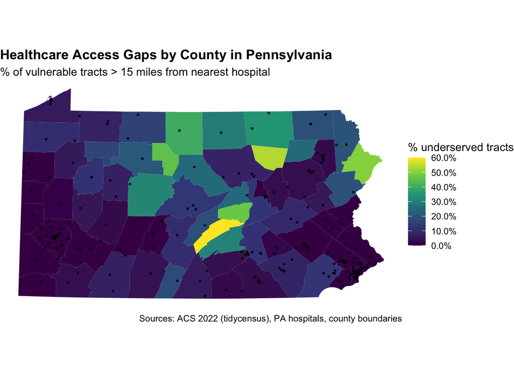

```r
library(ggplot2)
library(scales)
library(dplyr)

# join county-level stats to county geometries
counties_map <- pa_counties_p %>%
  left_join(county_summary, by = c("COUNTY_NAM" = "COUNTY"))

# choropleth filled by % underserved; hospitals as points
ggplot() +
  geom_sf(data = counties_map, aes(fill = pct_underserved), color = NA) +
  geom_sf(data = hospitals_p, size = 0.6, alpha = 0.7) +
  scale_fill_viridis_c(
    name = "% underserved tracts",
    labels = label_percent(accuracy = 0.1, scale = 1),
    na.value = "grey90"
  ) +
  labs(
    title = "Healthcare Access Gaps by County in Pennsylvania",
    subtitle = "% of vulnerable tracts > 15 miles from nearest hospital",
    caption = "Sources: ACS 2022 (tidycensus), PA hospitals, county boundaries"
  ) +
  theme_void() +
  theme(
    legend.position = "right",
    plot.title = element_text(face = "bold")
  )
```

**Requirements:** - Fill counties by percentage of vulnerable tracts that are underserved - Include hospital locations as points - Use an appropriate color scheme - Include clear title, subtitle, and caption - Use `theme_void()` or similar clean theme - Add a legend with formatted labels

### Map 2: Detailed Vulnerability Map

Create a map highlighting underserved vulnerable tracts.

**Your Task:**

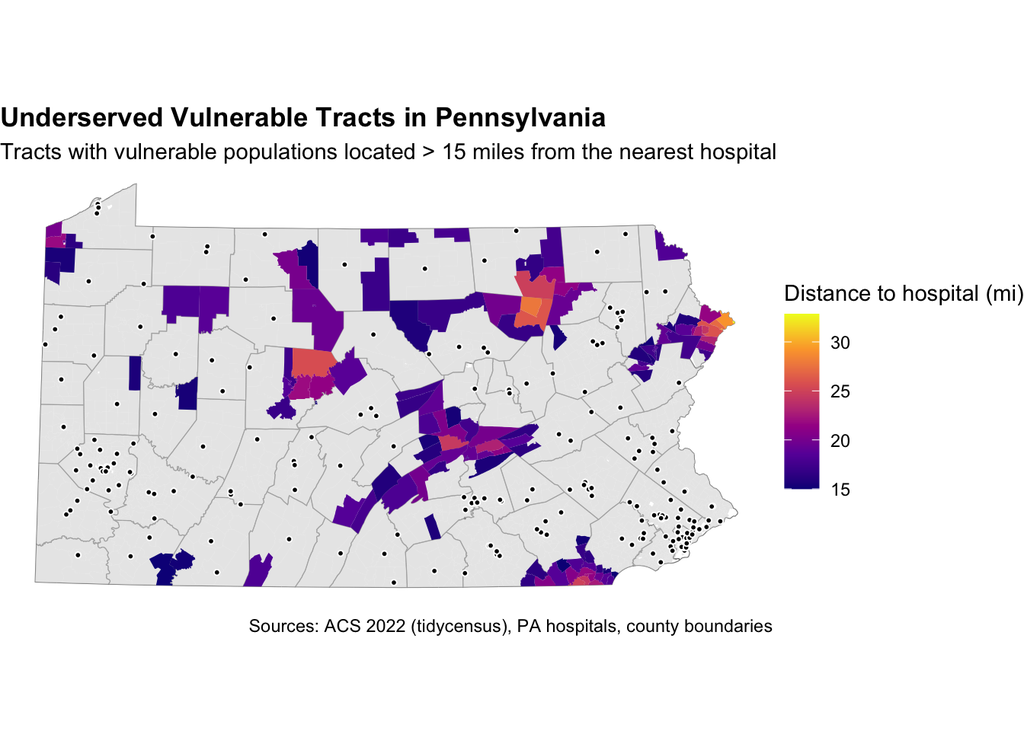

```r
# Create detailed tract-level map
# Data prep
tracts_map <- vulnerable_tracts_dist
underserved_tracts <- tracts_map %>% filter(underserved)

ggplot() +
  # context: county boundaries
  geom_sf(data = pa_counties_p, fill = NA, color = "grey50", linewidth = 0.2) +
  # all vulnerable tracts (muted)
  geom_sf(data = tracts_map, fill = "grey85", color = NA, alpha = 0.6) +
  # underserved vulnerable tracts (highlight)
  geom_sf(data = underserved_tracts, aes(fill = dist_to_hosp_mi), color = NA) +
  # hospitals
  geom_sf(data = hospitals_p, shape = 21, fill = "black", color = "white", size = 1) +
  scale_fill_viridis_c(
    name = "Distance to hospital (mi)",
    option = "C",
    limits = c(15, max(underserved_tracts$dist_to_hosp_mi, na.rm = TRUE)),
    oob = scales::squish
  ) +
  labs(
    title = "Underserved Vulnerable Tracts in Pennsylvania",
    subtitle = "Tracts with vulnerable populations located > 15 miles from the nearest hospital",
    caption = "Sources: ACS 2022 (tidycensus), PA hospitals, county boundaries"
  ) +
  theme_void() +
  theme(
    legend.position = "right",
    plot.title = element_text(face = "bold")
  )
```

**Requirements:** - Show underserved vulnerable tracts in a contrasting color - Include county boundaries for context - Show hospital locations - Use appropriate visual hierarchy (what should stand out?) - Include informative title and subtitle

### Chart: Distribution Analysis

Create a visualization showing the distribution of distances to hospitals for vulnerable populations.

**Your Task:**

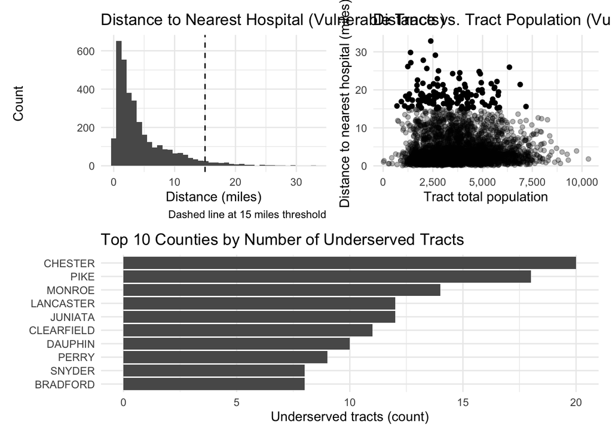

```r
# Create distribution visualization
# Histogram of distances (vulnerable tracts)
p_hist <- ggplot(vulnerable_tracts_dist, aes(x = dist_to_hosp_mi)) +
  geom_histogram(bins = 40) +
  geom_vline(xintercept = 15, linetype = "dashed") +
  labs(
    title = "Distance to Nearest Hospital (Vulnerable Tracts)",
    x = "Distance (miles)", y = "Count",
    caption = "Dashed line at 15 miles threshold"
  ) +
  theme_minimal()

# Top-10 counties by underserved tracts (requires county_summary from Step 6)
top10_underserved <- county_summary %>%
  slice_max(n_underserved, n = 10) %>%
  mutate(COUNTY = reorder(COUNTY, n_underserved))

p_bar <- ggplot(top10_underserved, aes(x = COUNTY, y = n_underserved)) +
  geom_col() +
  coord_flip() +
  labs(
    title = "Top 10 Counties by Number of Underserved Tracts",
    x = NULL, y = "Underserved tracts (count)"
  ) +
  theme_minimal()

# Scatter: distance vs. population, highlighting underserved tracts
p_scatter <- ggplot(vulnerable_tracts_dist,
                    aes(x = total_pop, y = dist_to_hosp_mi, alpha = underserved)) +
  geom_point() +
  scale_x_continuous(labels = comma) +
  scale_alpha_manual(values = c(`TRUE` = 1, `FALSE` = 0.3), guide = "none") +
  labs(
    title = "Distance vs. Tract Population (Vulnerable Tracts)",
    x = "Tract total population", y = "Distance to nearest hospital (miles)"
  ) +
  theme_minimal()

# Display
(p_hist | p_scatter) / p_bar
```

```r
# Brief interpretation
cat("Interpretation:",
    "Most vulnerable tracts lie within 15 miles, but a right tail exceeds the threshold.",
    "Underserved tracts concentrate in a small set of counties.",
    "Higher-population tracts are not necessarily farther from hospitals; gaps are mainly geographic.\n")
```

[output not shown]

**Suggested chart types:** - Histogram or density plot of distances - Box plot comparing distances across regions - Bar chart of underserved tracts by county - Scatter plot of distance vs. vulnerable population size

**Requirements:** - Clear axes labels with units - Appropriate title - Professional formatting - Brief interpretation (1-2 sentences as a caption or in text)

## Part 3: Bring Your Own Data Analysis

Choose your own additional spatial dataset and conduct a supplementary analysis.

### Your Analysis

**Your Task:**

1. **Find and load additional data**
   - Document your data source
   - Check and standardize the CRS
   - Provide basic summary statistics

```r
# Config
crs_proj <- 2272          # Pennsylvania South State Plane (US feet)
buf_ft   <- 2640          # 0.5 mile ≈ 2640 ft

# Load schools
schools <- st_read(here("Assignments", "assignment_2", "data","Schools.geojson"), quiet = TRUE) %>%
  st_transform(crs_proj)

# Get Philadelphia tracts with children population (ACS 2022)
# B09001_001 = total population under 18
acs_children <- get_acs(
  geography = "tract",
  variables = "B09001_001",
  state = "PA",
  county = "Philadelphia",
  year = 2022,
  geometry = TRUE
) %>%
  st_transform(crs_proj) %>%
  rename(child_pop = estimate) %>%
  select(GEOID, NAME, child_pop, geometry) %>%
  mutate(
    tract_name = str_replace(NAME, ", Philadelphia County, Pennsylvania", "")
  )

# Build Philadelphia boundary from tracts
phila_boundary <- acs_children %>% st_union() %>% st_as_sf()

# Data overview
cat("\n===== DATA OVERVIEW =====\n")
```

```
===== DATA OVERVIEW =====
```

```r
cat("\n-- Schools --\n")
```

```
-- Schools --
```

```r
print(schools)
```

```
Simple feature collection with 495 features and 14 fields
Geometry type: POINT
Dimension:     XY
Bounding box:  xmin: 2664437 ymin: 219220.7 xmax: 2745960 ymax: 301940.8
Projected CRS: NAD83 / Pennsylvania South (ftUS)
First 10 features:
         aun school_num location_id                    school_name
1  226518902         NA        <NA> ST MARYS INTERPAROCHIAL SCHOOL
2  226518722         NA        <NA>               ST MARTHA SCHOOL
3  226514052         NA        <NA>           MATERNITY BVM SCHOOL
4  226514852         NA        <NA>     OUR LADY OF CALVARY SCHOOL
5  226511102         NA        <NA>         CHRIST THE KING SCHOOL
6  300511820         NA        <NA>     BEGINNINGS LEARNING CENTER
7  226511232         NA        <NA>                 JUBILEE SCHOOL
8  226514112         NA        <NA>              MILL CREEK SCHOOL
```

[output cut: 35 more lines]

```r
cat("\nCRS:\n"); print(st_crs(schools))
```

```
CRS:
```

[output not shown]

```r
cat("\nField summary:\n"); glimpse(schools)
```

```
Field summary:
```

```
Rows: 495
Columns: 15
$ aun               <int> 226518902, 226518722, 226514052, 226514852, 22651110…
$ school_num        <int> NA, NA, NA, NA, NA, NA, NA, NA, NA, NA, NA, NA, NA, …
$ location_id       <chr> NA, NA, NA, NA, NA, NA, NA, NA, NA, NA, NA, NA, NA, …
$ school_name       <chr> "ST MARYS INTERPAROCHIAL SCHOOL", "ST MARTHA SCHOOL"…
$ school_name_label <chr> "ST MARYS INTERPAROCHIAL SCHOOL", "ST MARTHA SCHOOL"…
$ street_address    <chr> "440 LOCUST ST", "11321 ACADEMY RD", "9322 OLD BUSTL…
$ zip_code          <chr> "19106", "19154", "19115", "19154", "19114", "19147"…
$ phone_number      <chr> "(215) 923-7522", "(215) 632-0320", "(215) 673-0235"…
$ grade_level       <chr> "ELEMENTARY/MIDDLE", "ELEMENTARY/MIDDLE", "ELEMENTAR…
$ grade_org         <chr> "K-8", "PREK-8", "PREK-8", "PREK-8", "PREK-8", "PREK…
$ enrollment        <int> NA, NA, NA, NA, NA, NA, NA, NA, NA, NA, NA, NA, NA, …
$ type              <int> 3, 3, 3, 3, 3, 3, 3, 3, 3, 3, 3, 3, 3, 3, 1, 1, 1, 1…
$ type_specific     <chr> "ARCHDIOCESE", "ARCHDIOCESE", "ARCHDIOCESE", "ARCHDI…
$ objectid          <int> 1, 2, 3, 4, 5, 6, 7, 8, 9, 10, 11, 12, 13, 14, 15, 1…
$ geometry          <POINT [US_survey_foot]> POINT (2697499 233938.6), POINT (…
```

```r
cat("\nCoordinate summary:\n"); print(summary(st_coordinates(schools)))
```

```
Coordinate summary:
```

```
       X                 Y
 Min.   :2664437   Min.   :219221
 1st Qu.:2687329   1st Qu.:240118
 Median :2694639   Median :251800
 Mean   :2697454   Mean   :253321
 3rd Qu.:2704980   3rd Qu.:266685
 Max.   :2745960   Max.   :301941
```

```r
cat("\n-- Philadelphia tracts (ACS 2022) --\n")
```

```
-- Philadelphia tracts (ACS 2022) --
```

```r
print(acs_children)
```

```
Simple feature collection with 408 features and 4 fields
Geometry type: MULTIPOLYGON
Dimension:     XY
Bounding box:  xmin: 2660586 ymin: 204667.4 xmax: 2750104 ymax: 304965.3
Projected CRS: NAD83 / Pennsylvania South (ftUS)
First 10 features:
         GEOID                                                  NAME child_pop
1  42101001500    Census Tract 15; Philadelphia County; Pennsylvania       563
2  42101001800    Census Tract 18; Philadelphia County; Pennsylvania       471
3  42101002802 Census Tract 28.02; Philadelphia County; Pennsylvania       806
4  42101004001 Census Tract 40.01; Philadelphia County; Pennsylvania       574
5  42101006300    Census Tract 63; Philadelphia County; Pennsylvania      1226
6  42101007700    Census Tract 77; Philadelphia County; Pennsylvania       102
7  42101008701 Census Tract 87.01; Philadelphia County; Pennsylvania       427
8  42101011000   Census Tract 110; Philadelphia County; Pennsylvania       808
```

[output cut: 24 more lines]

```r
cat("\nCRS:\n"); print(st_crs(acs_children))
```

```
CRS:
```

[output not shown]

```r
cat("\nChild population summary:\n"); print(summary(acs_children$child_pop))
```

```
Child population summary:
```

```
   Min. 1st Qu.  Median    Mean 3rd Qu.    Max.
    0.0   368.5   744.5   839.7  1142.0  3894.0
```

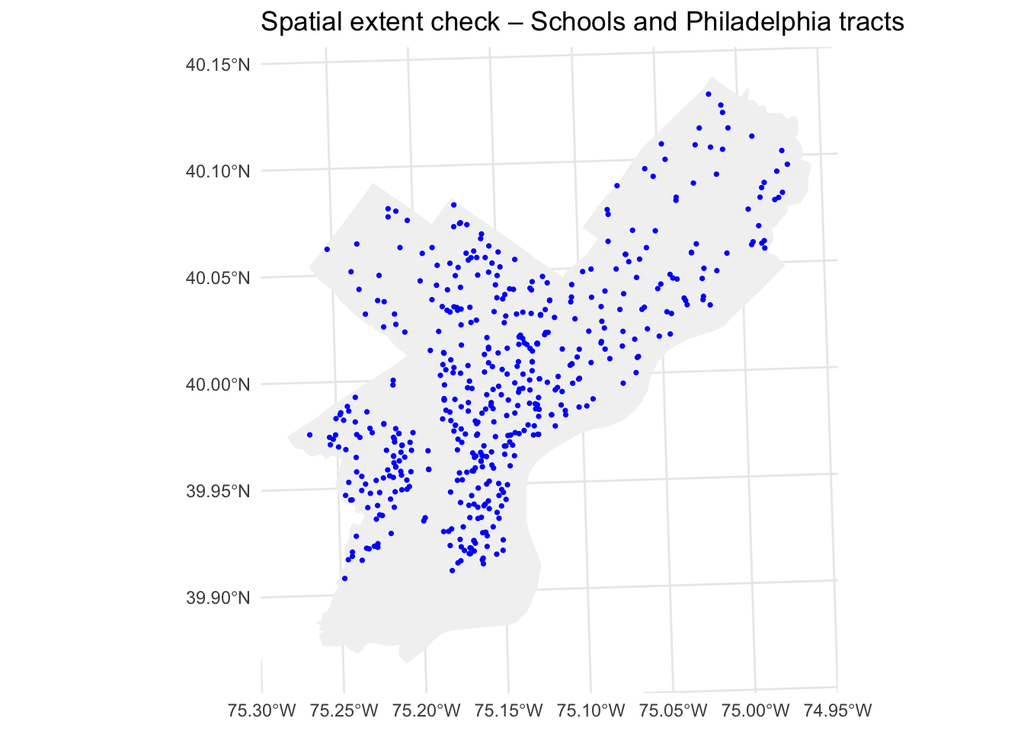

```r
# Quick visualization check
ggplot() +
  geom_sf(data = acs_children, fill = "grey95", color = NA) +
  geom_sf(data = schools, color = "blue", size = 0.6) +
  labs(title = "Spatial extent check – Schools and Philadelphia tracts") +
  theme_minimal()
```

Write a clear research statement that your analysis will answer.

**Examples:** - “Do vulnerable tracts have adequate public transit access to hospitals?” - “Are EMS stations appropriately located near vulnerable populations?” - “Do areas with low vehicle access have worse hospital access?”

## Do areas in Philadelphia with higher concentrations of children have adequate spatial access to schools within a 0.5-mile walking distance?

3. **Conduct spatial analysis**

Use at least TWO spatial operations to answer your research question.

**Required operations (choose 2+):** - Buffers - Spatial joins - Spatial filtering with predicates - Distance calculations - Intersections or unions - Point-in-polygon aggregation

**Your Task:**

```r
# Your spatial analysis
# Build 0.5-mile service buffer of schools
school_buf <- schools %>%
  st_buffer(buf_ft) %>%      # service area
  st_union() %>%             # dissolve overlaps
  st_as_sf()

# Tract-level coverage and areal-weighted children counts
area_total   <- st_area(acs_children)
overlap_idx  <- st_intersects(acs_children, school_buf)
has_overlap  <- lengths(overlap_idx) > 0
area_covered <- units::set_units(0, "ft^2")
area_covered[has_overlap] <- st_area(st_intersection(acs_children[has_overlap, ], school_buf))

tracts_cov <- acs_children %>%
  mutate(
    area_total   = area_total,
    area_covered = area_covered,
    pct_covered  = pmin(1, as.numeric(area_covered / area_total)),
    children_in_service = child_pop * pct_covered,
    children_in_gap     = child_pop * (1 - pct_covered),
    access_flag = case_when(
      pct_covered >= 0.90 ~ "Well covered (≥90%)",
      pct_covered >= 0.50 ~ "Partially covered (50–90%)",
      TRUE               ~ "Gap (<50%)"
    )
  )


# Citywide summaries
city_summary <- tracts_cov %>%
  st_drop_geometry() %>%
  summarise(
    tracts              = n(),
    children_total      = sum(child_pop, na.rm = TRUE),
    children_served     = sum(children_in_service, na.rm = TRUE),
    children_gap        = sum(children_in_gap, na.rm = TRUE),
    pct_children_served = round(100 * children_served / children_total, 1),
    pct_children_gap    = round(100 * children_gap / children_total, 1)
  )
cat("\n===== CITYWIDE SUMMARY =====\n")
```

```
===== CITYWIDE SUMMARY =====
```

```r
print(city_summary)
```

```
  tracts children_total children_served children_gap pct_children_served
1    408         342585        325716.3     16354.73                95.1
  pct_children_gap
1              4.8
```

```r
band_summary <- tracts_cov %>%
  st_drop_geometry() %>%
  group_by(access_flag) %>%
  summarise(
    n_tracts     = n(),
    children_sum = sum(child_pop, na.rm = TRUE),
    .groups = "drop"
  ) %>%
  arrange(match(access_flag, c("Well covered (≥90%)","Partially covered (50–90%)","Gap (<50%)")))
cat("\n===== COVERAGE BANDS =====\n")
```

```
===== COVERAGE BANDS =====
```

```r
print(band_summary)
```

```
# A tibble: 3 × 3
  access_flag                n_tracts children_sum
  <chr>                         <int>        <dbl>
1 Well covered (≥90%)             322       293209
2 Partially covered (50–90%)       57        41085
3 Gap (<50%)                       29         8291
```

```r
top_gap_tracts <- tracts_cov %>%
  st_drop_geometry() %>%
  transmute(
    tract_name,
    GEOID,
    child_pop,
    pct_covered = round(pct_covered, 3),
    children_in_gap = round(children_in_gap)
  ) %>%
  arrange(desc(children_in_gap)) %>%
  slice_head(n = 10)
cat("\n===== TOP 10 GAP TRACTS =====\n")
```

```
===== TOP 10 GAP TRACTS =====
```

```r
print(top_gap_tracts)
```

```
                                               tract_name       GEOID child_pop
1  Census Tract 348.02; Philadelphia County; Pennsylvania 42101034802      1523
2  Census Tract 347.01; Philadelphia County; Pennsylvania 42101034701      1556
3  Census Tract 363.03; Philadelphia County; Pennsylvania 42101036303      1972
4     Census Tract 361; Philadelphia County; Pennsylvania 42101036100      1162
5     Census Tract 373; Philadelphia County; Pennsylvania 42101037300      1344
6     Census Tract 358; Philadelphia County; Pennsylvania 42101035800      1416
7  Census Tract 357.02; Philadelphia County; Pennsylvania 42101035702      1036
8  Census Tract 365.02; Philadelphia County; Pennsylvania 42101036502       933
9     Census Tract 346; Philadelphia County; Pennsylvania 42101034600       552
10 Census Tract 337.01; Philadelphia County; Pennsylvania 42101033701      1904
   pct_covered children_in_gap
1        0.305            1058
2        0.509             764
3        0.657             676
4        0.457             631
5        0.534             626
6        0.580             595
7        0.447             572
8        0.447             516
9        0.092             501
10       0.758             460
```

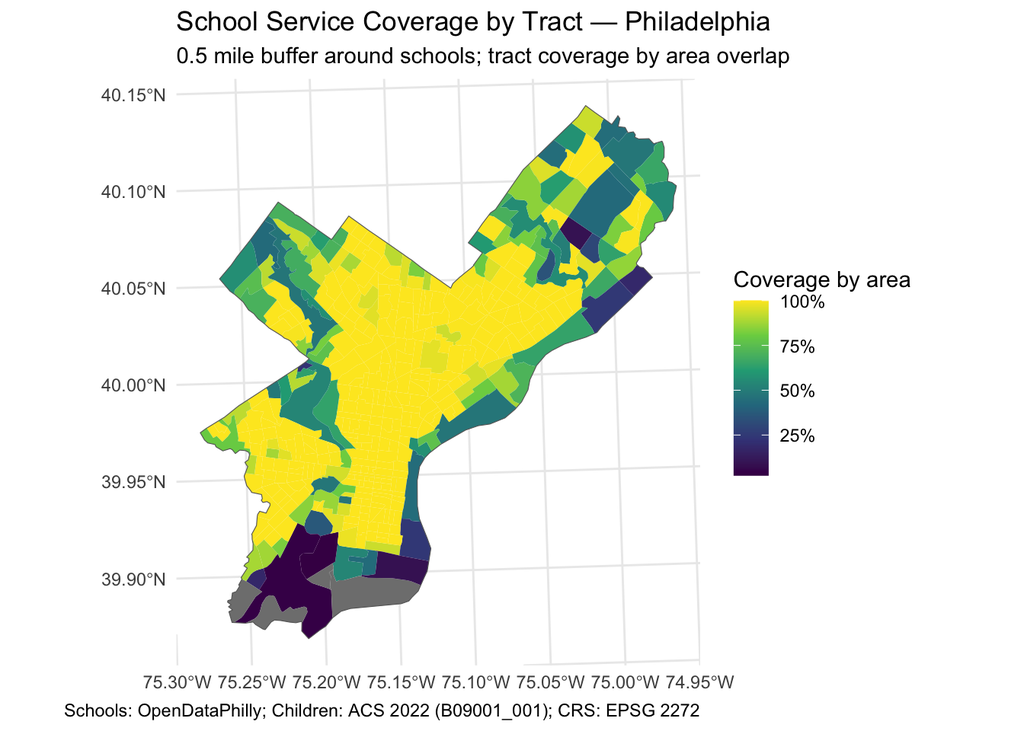

```r
# Maps
# Coverage percent choropleth
ggplot() +
  geom_sf(data = tracts_cov, aes(fill = pct_covered), color = NA) +
  geom_sf(data = phila_boundary, fill = NA, color = "grey40", linewidth = 0.2) +
  scale_fill_viridis_c(name = "Coverage by area", labels = scales::percent_format(accuracy = 1)) +
  labs(
    title = "School Service Coverage by Tract — Philadelphia",
    subtitle = "0.5 mile buffer around schools; tract coverage by area overlap",
    caption = "Schools: OpenDataPhilly; Children: ACS 2022 (B09001_001); CRS: EPSG 2272"
  ) +
  theme_minimal()
```

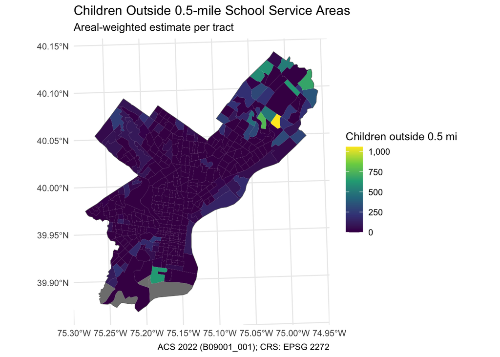

```r
# Children outside service areas (areal-weighted)
ggplot() +
  geom_sf(data = tracts_cov, aes(fill = children_in_gap), color = NA) +
  geom_sf(data = phila_boundary, fill = NA, color = "grey40", linewidth = 0.2) +
  scale_fill_viridis_c(name = "Children outside 0.5 mi", labels = scales::comma) +
  labs(
    title = "Children Outside 0.5-mile School Service Areas",
    subtitle = "Areal-weighted estimate per tract",
    caption = "ACS 2022 (B09001_001); CRS: EPSG 2272"
  ) +
  theme_minimal()
```

**Analysis requirements:** - Clear code comments explaining each step - Appropriate CRS transformations - Summary statistics or counts - At least one map showing your findings - Brief interpretation of results (3-5 sentences)

**Your interpretation:**

Philadelphia tracts show high access overall: 95.1% of children live within 0.5 miles of a school; 4.8% are outside service areas. Coverage by tract: 322 well covered (≥90%), 57 partially covered (50–90%), 29 gaps (<50%), totaling 293,209, 41,085, and 8,291 children respectively. The largest unmet-need tracts by children outside service areas include Census Tracts 348.02, 347.01, 363.03, 361, 373, 358, 357.02, 365.02, 346, 337.01. Maps confirm a small number of edge tracts drive most gaps; prioritizing these for new sites or access improvements would yield the highest impact.

## Finally - A few comments about your incorporation of feedback!

I used include=FALSE to hide my API, removed the empty [], deleted some overly long instructions and improved the variable names to make the code easier to read.